# Spotting the weird ones

Rob J Hyndman

1 December 2026

`robjhyndman.com/wombat2026`

## The weird package for R

- Functions and data sets for *That’s weird: Anomaly detection using R* ([`OTexts.com/weird`](https://OTexts.com/weird))
- All packages needed to run the examples are also loaded

```r
library(weird)
```

## What is an anomaly?

01

1. What is an anomaly?
2. Shiraz value for money
3. Approximate extreme surprisal probabilities
4. Old Faithful eruptions
5. French mortality rates
6. PBS prescriptions
7. Summary

Photo: Bob Jenkin, [Pexels](https://www.pexels.com/photo/standout-blue-peacock-among-yellow-duck-toys-31558264/)

## Is this an anomaly?

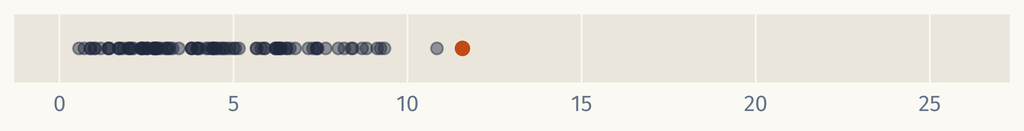

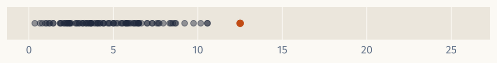

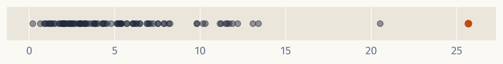

All points were randomly generated from the **same** $\chi^2_5$ distribution.

## Spot the anomaly

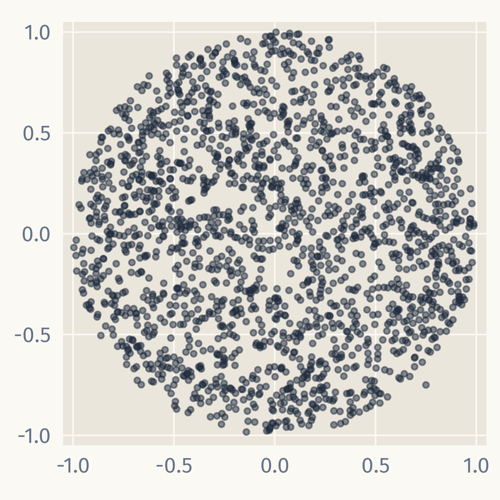

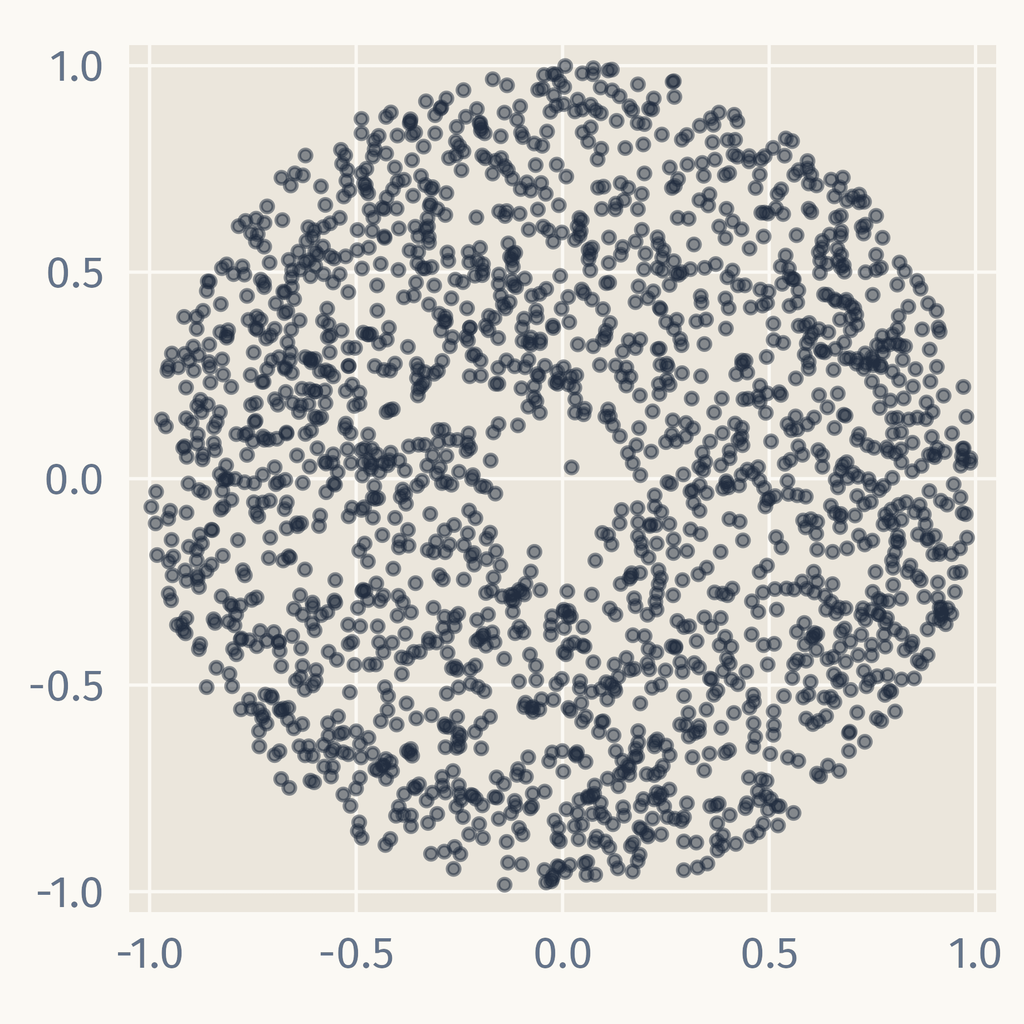

An anomaly is an observation in a region of **low probability density**.

## Are there any anomalies here?

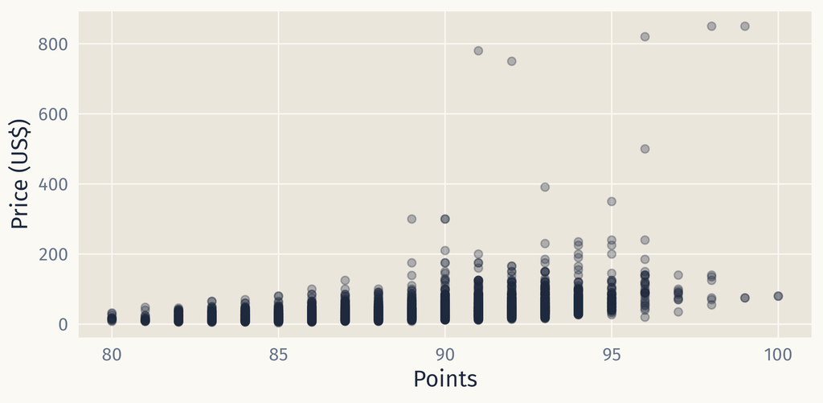

## Are there any anomalies here?

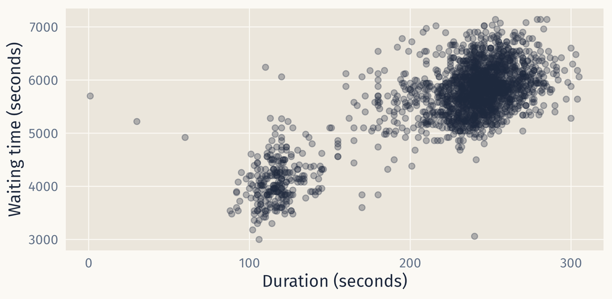

## Surprisals

The **surprisal** of observation $y_i$ under density $f$: $s_i = -\log f(y_i)$.

- Small density $\Leftrightarrow$ large surprisal.
- $s_i$ is one number, whatever $y_i$ is: multivariate, functional, image, …
- $f$ can be assumed, estimated, conditional, …

Information theory

Expected surprisal = entropy

Machine learning

Log loss  
(cross-entropy)

Statistics

Sum of surprisals = $-$log likelihood

Anomalies are observations with extreme surprisal values.

## Surprisal probabilities

The probability of an observation at least as unlikely as $y_i$ under $f$:

$$p_i = \mathbb{P}\big(f(Y) \le f(y_i)\big)
= \mathbb{P}\big(-\log f(Y) \ge s_i\big), \qquad Y \sim f$$

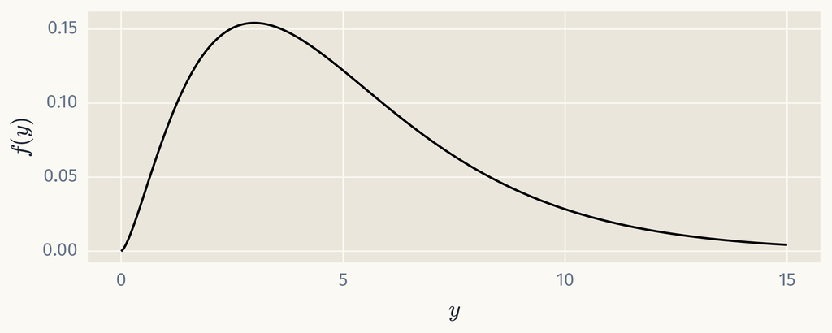

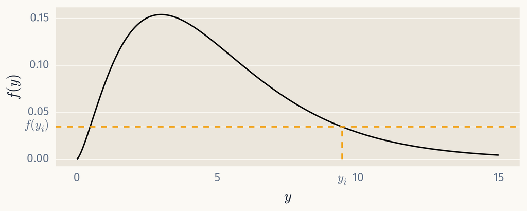

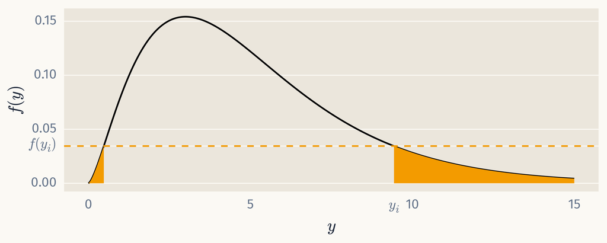

An observation is an **anomaly with respect to $f$** if $p_i < \alpha$.

## Surprisal probabilities in R

`surprisals_prob(object, distribution, ...)` returns a surprisal probability for each observation in `object` under model `distribution`.

- `object`: a vector, matrix, data frame or factor, or a fitted `lm`, `glm` or `gam` (which supplies data and distribution).
- `distribution`: any **distributional** object; a kernel density estimate by default for numerical data.

## Surprisal probabilities in R

```r
N01 <- dist_normal(mean = 0, sd = 1)
tibble(y = unlist(generate(N01, times = 1000))) |>
  mutate(p = surprisals_prob(y, distribution = N01)) |>
  arrange(p)
```

```
# A tibble: 1,000 × 1
        y
    <dbl>
1  0.521
2 -1.08
3  0.139
4 -0.0847
5 -0.667
# ℹ 995 more rows
```

```
# A tibble: 1,000 × 2
        y     p
    <dbl> <dbl>
1  0.521  0.603
2 -1.08   0.280
3  0.139  0.889
4 -0.0847 0.932
5 -0.667  0.505
# ℹ 995 more rows
```

```
# A tibble: 1,000 × 2
      y        p
  <dbl>    <dbl>
1  3.42 0.000634
2  3.14 0.00167
3 -3.05 0.00230
4 -2.96 0.00304
5 -2.89 0.00390
# ℹ 995 more rows
```

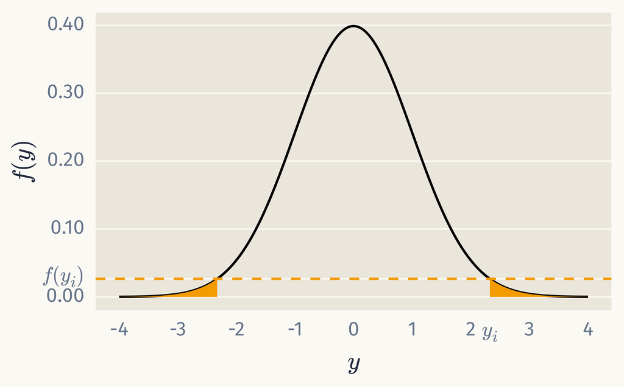

No anomalies here, yet flagging $p_i < \alpha$ gives about $n\alpha$ false alarms.

## The boxplot rule

Anomaly if $y_i < Q_1 - 1.5\,\text{IQR}$ or $y_i > Q_3 + 1.5\,\text{IQR}$.

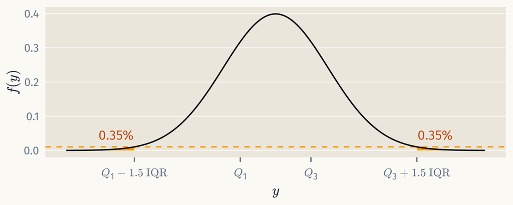

Implicitly assumes a **symmetric unimodal** density

Normal density false alarm rate: $\alpha \approx 0.007$

## Shiraz value for money

02

1. What is an anomaly?
2. Shiraz value for money
3. Approximate extreme surprisal probabilities
4. Old Faithful eruptions
5. French mortality rates
6. PBS prescriptions
7. Summary

Photo: Graham, [CC BY 2.0](https://commons.wikimedia.org/wiki/File:Wine_grapes_nearing_harvest_in_Ontario-also_example_of_trellis_wire.jpg)

## Shiraz value for money

```r
wine_reviews <- fetch_wine_reviews() |>
  filter(variety %in% c("Shiraz", "Syrah")) |>
  select(-variety, -region)
```

```
# A tibble: 4,553 × 7
  country state        winery       year points price description
  <chr>   <chr>        <chr>       <dbl>  <dbl> <dbl> <chr>
1 US      California   Rideau       2014     87    44 Baked red cherry, crush…
2 US      California   Alta Colina  2012     91    46 Dark and thick in the g…
3 US      California   Big Basin    2013     91    36 Bradley Brown's appella…
4 US      California   Kenwood      2005     88    25 Black as a moonless nig…
5 Israel  Judean Hills Yatir        2011     90    50 This wine features plea…
# ℹ 4,548 more rows
```

*Wine Enthusiast* reviews: week of 15 June 2017

Data from [`kaggle.com`](https://www.kaggle.com/datasets/zynicide/wine-reviews)

## Shiraz value for money

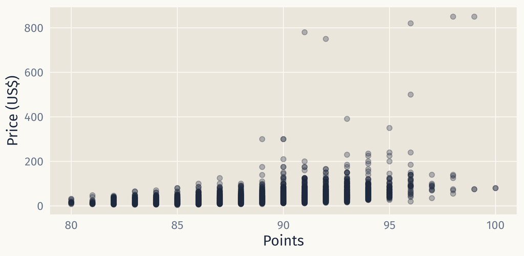

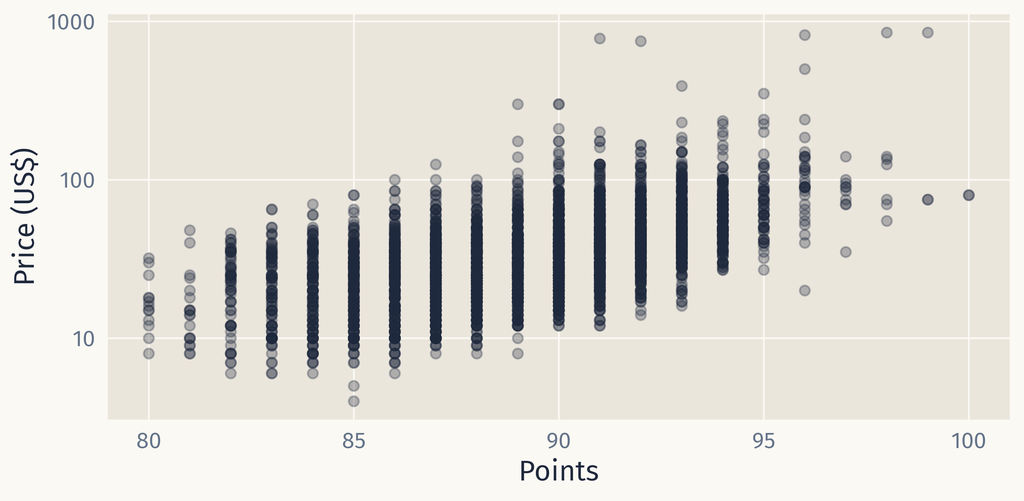

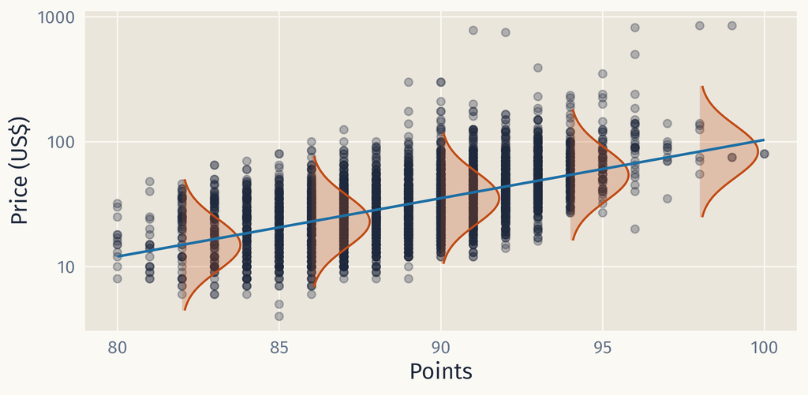

$\log\text{Price} \sim \text{N}(\mu, \sigma^2)$  
$\mu = a + b\,\text{Points}$

## Shiraz value for money

```r
wine_lm <- lm(log(price) ~ points, data = wine_reviews)
wine_reviews <- wine_reviews |>
  mutate(p = surprisals_prob(wine_lm, loo = TRUE))
wine_reviews |> arrange(p)
```

```
# A tibble: 4,553 × 8
  country state        winery       year points price description            p
  <chr>   <chr>        <chr>       <dbl>  <dbl> <dbl> <chr>              <dbl>
1 US      California   Rideau       2014     87    44 Baked red cherry,… 0.263
2 US      California   Alta Colina  2012     91    46 Dark and thick in… 0.748
3 US      California   Big Basin    2013     91    36 Bradley Brown's a… 0.854
4 US      California   Kenwood      2005     88    25 Black as a moonle… 0.786
5 Israel  Judean Hills Yatir        2011     90    50 This wine feature… 0.474
# ℹ 4,548 more rows
```

```
# A tibble: 4,553 × 8
  country   state           winery    year points price description          p
  <chr>     <chr>           <chr>    <dbl>  <dbl> <dbl> <chr>            <dbl>
1 Australia South Australia Henschke  2009     91   780 This wine is… 5.84e-10
2 US        California      Law       2013     92   750 This is a po… 3.91e- 9
3 Australia South Australia Henschke  2010     96   820 Is this the … 2.23e- 7
4 Australia South Australia Penfolds  2008     98   850 This has all… 1.53e- 6
5 Italy     Tuscany         Tua Rita  2011     89   300 Mature black… 3.32e- 6
# ℹ 4,548 more rows
```

## Shiraz value for money

[interactive chart not shown]

17 anomalies (4.6 expected)

$p_i < 0.001$

## Approximate extreme surprisal probabilities

03

1. What is an anomaly?
2. Shiraz value for money
3. Approximate extreme surprisal probabilities
4. Old Faithful eruptions
5. French mortality rates
6. PBS prescriptions
7. Summary

Photo: Basile Morin, [CC BY-SA 4.0](https://commons.wikimedia.org/wiki/File:Karst_peaks_with_sea_of_clouds_at_sunrise,_South_view_from_the_top_of_Mount_Nam_Xay,_Vang_Vieng,_Laos.jpg)

## What if $f$ is wrong?

- If $f$ is wrong, $p_i$ is wrong.
- But by extreme value theory, the largest surprisals are approximately Generalised Pareto (GPD), even if $f$ is wrong.
- So $p_i \approx$ tail probability of a GPD fitted to the largest surprisals.

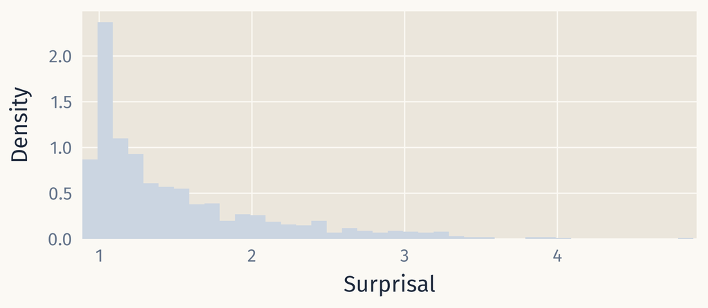

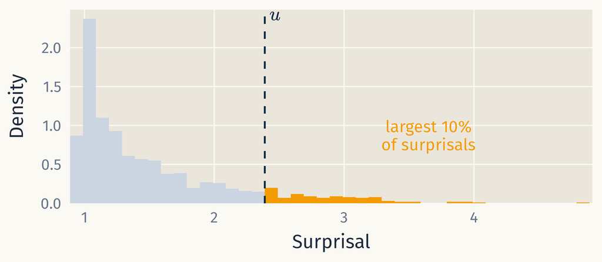

[video not shown]

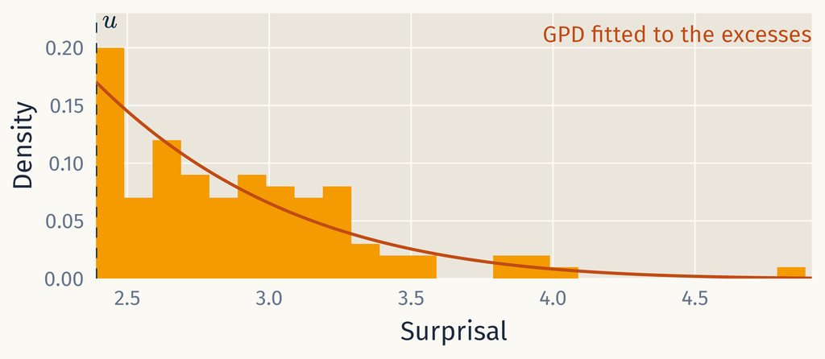

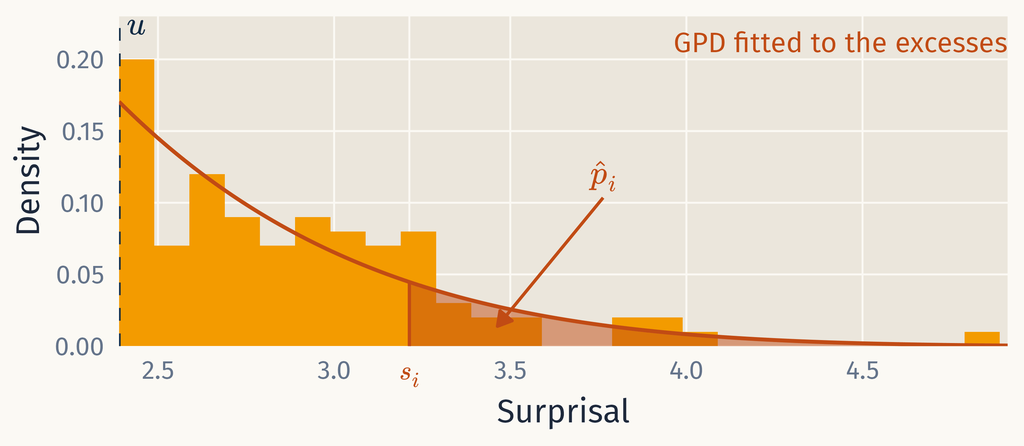

Only needs $f$ to get the *ordering* of the extreme surprisals correct.

## Shiraz value for money

```r
wine_lm <- lm(log(price) ~ points, data = wine_reviews)
wine_reviews <- wine_reviews |>
  mutate(p = surprisals_prob(wine_lm, loo = TRUE))
wine_reviews |> arrange(p)
```

```r
wine_lm <- lm(log(price) ~ points, data = wine_reviews)
wine_reviews <- wine_reviews |>
  mutate(p = surprisals_prob(wine_lm, loo = TRUE, approximation = "gpd"))
wine_reviews |> arrange(p)
```

```
# A tibble: 4,553 × 8
  country   state           winery    year points price description            p
  <chr>     <chr>           <chr>    <dbl>  <dbl> <dbl> <chr>              <dbl>
1 Australia South Australia Henschke  2009     91   780 This wine is r… 5.84e-10
2 US        California      Law       2013     92   750 This is a powe… 3.91e- 9
3 Australia South Australia Henschke  2010     96   820 Is this the Yi… 2.23e- 7
4 Australia South Australia Penfolds  2008     98   850 This has all t… 1.53e- 6
5 Italy     Tuscany         Tua Rita  2011     89   300 Mature black f… 3.32e- 6
# ℹ 4,548 more rows
```

```
# A tibble: 4,553 × 8
  country   state           winery    year points price description            p
  <chr>     <chr>           <chr>    <dbl>  <dbl> <dbl> <chr>              <dbl>
1 Australia South Australia Henschke  2009     91   780 This wine is ra… 1.14e-4
2 US        California      Law       2013     92   750 This is a power… 1.52e-4
3 Australia South Australia Henschke  2010     96   820 Is this the Yin… 3.15e-4
4 Australia South Australia Penfolds  2008     98   850 This has all th… 4.80e-4
5 Italy     Tuscany         Tua Rita  2011     89   300 Mature black fr… 5.78e-4
# ℹ 4,548 more rows
```

## Shiraz value for money

[interactive chart not shown]

9 anomalies (4.6 expected)

$p_i < 0.001$ Normal only

## Old Faithful eruptions

04

1. What is an anomaly?
2. Shiraz value for money
3. Approximate extreme surprisal probabilities
4. Old Faithful eruptions
5. French mortality rates
6. PBS prescriptions
7. Summary

Photo: NPS / Jacob W. Frank, public domain

## Old Faithful eruptions

```r
oldfaithful
```

```
# A tibble: 2,097 × 4
  time                recorded_duration duration waiting
  <dttm>              <chr>                <dbl>   <dbl>
1 2017-01-14 00:06:00 3m 16s                 196    5940
2 2017-01-26 14:27:00 ~4m                    240    5820
3 2017-01-27 23:57:00 2m 1s                  121    3900
4 2017-01-30 15:09:00 ~4m                    240    5280
5 2017-01-31 13:27:00 ~3.5m                  210    5580
# ℹ 2,092 more rows
```

Eruptions: Jan 2017–Dec 2023

Data from [`geysertimes.org`](https://geysertimes.org)

## Old Faithful eruptions

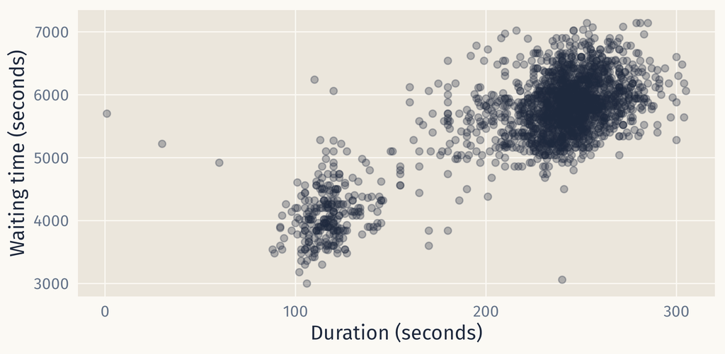

## Old Faithful eruptions

```r
oldfaithful$p <- surprisals_prob(
  oldfaithful[, c("duration", "waiting")],
  loo = TRUE,
  approximation = "gpd"
)
oldfaithful |>
  arrange(p)
```

```
# A tibble: 2,097 × 5
  time                recorded_duration duration waiting      p
  <dttm>              <chr>                <dbl>   <dbl>  <dbl>
1 2017-01-14 00:06:00 3m 16s                 196    5940 0.0901
2 2017-01-26 14:27:00 ~4m                    240    5820 0.1
3 2017-01-27 23:57:00 2m 1s                  121    3900 0.1
4 2017-01-30 15:09:00 ~4m                    240    5280 0.1
5 2017-01-31 13:27:00 ~3.5m                  210    5580 0.1
# ℹ 2,092 more rows
```

```
# A tibble: 2,097 × 5
  time                recorded_duration duration waiting     p
  <dttm>              <chr>                <dbl>   <dbl> <dbl>
1 2018-04-25 19:08:00 1s                       1    5700     0
2 2018-09-29 22:10:00 ~4m01s                 241    4500     0
3 2020-06-01 21:04:00 2 minutes              120    6060     0
4 2020-09-04 01:38:00 >1m 50s                110    6240     0
5 2022-12-03 16:20:00 ~4m                    240    3060     0
# ℹ 2,092 more rows
```

## Old Faithful eruptions

```r
dist_kde(oldfaithful[, c("duration", "waiting")]) |>
  gg_density(show_points = TRUE, colors = "#1e293b")
```

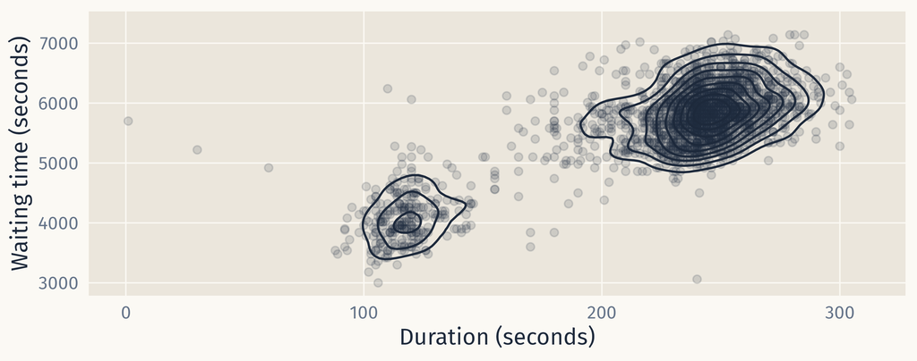

## Old Faithful eruptions

```r
dist_kde(oldfaithful[, c("duration", "waiting")]) |>
  gg_density(show_points = TRUE, colors = "#1e293b") +
  geom_point(data = filter(oldfaithful, p < 0.005), colour = "#c14b14")
```

[interactive chart not shown]

## Old Faithful eruptions

```r
oldfaithful |>
  gg_hdrboxplot(duration, waiting)
```

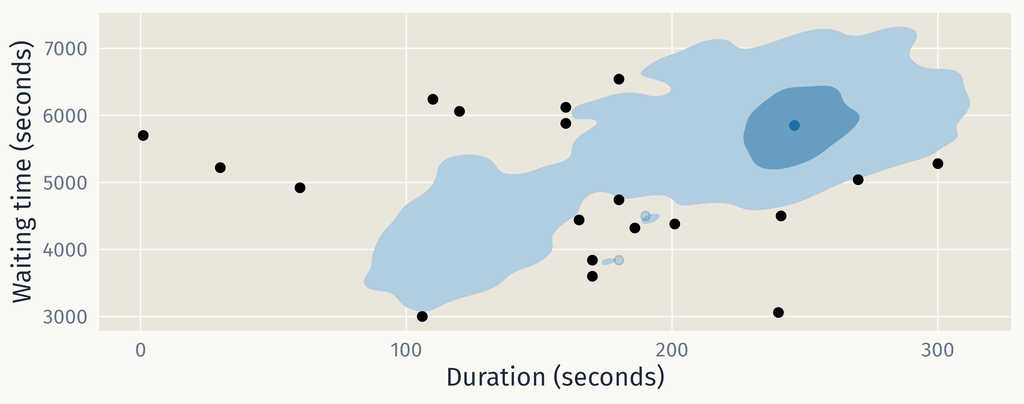

## French mortality rates

05

1. What is an anomaly?
2. Shiraz value for money
3. Approximate extreme surprisal probabilities
4. Old Faithful eruptions
5. French mortality rates
6. PBS prescriptions
7. Summary

Photo: Benh LIEU SONG, [CC BY-SA 4.0](https://commons.wikimedia.org/wiki/File:National_Cemetery_Douaumont.jpg)

## French mortality rates

```r
fr_mortality
```

```
# A tibble: 31,648 × 4
   Year   Age Sex    Mortality
  <int> <int> <chr>      <dbl>
1  1816     0 Female    0.187
2  1816     1 Female    0.0467
3  1816     2 Female    0.0339
4  1816     3 Female    0.0229
5  1816     4 Female    0.0160
# ℹ 31,643 more rows
```

Annual data: 1816–1999, ages 0–85+, by sex

Data from [`mortality.org`](https://www.mortality.org)

## French mortality rates

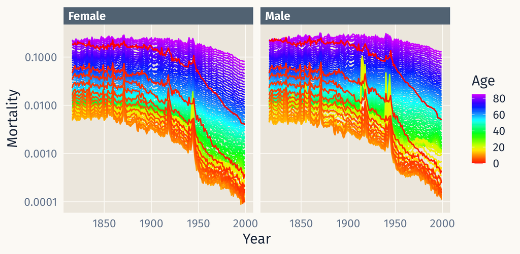

## Hampel identifier

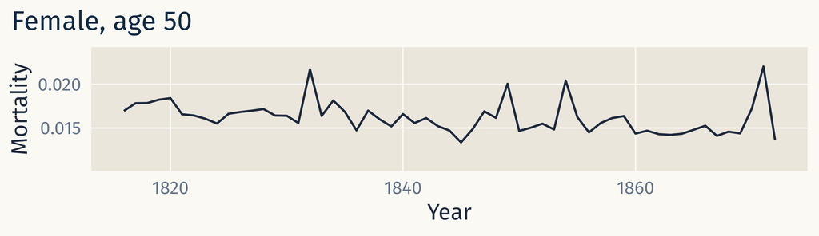

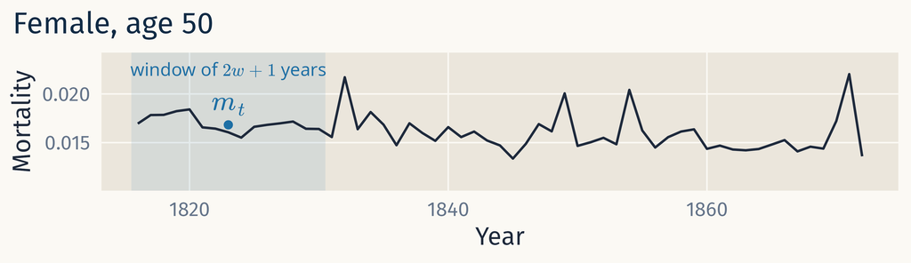

[video not shown]

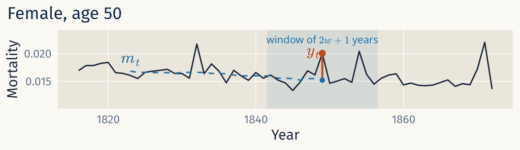

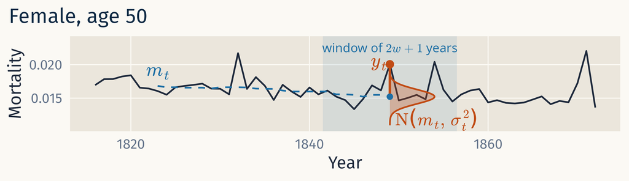

$$m_t = \text{median}(y_{t-w}, \dots, y_{t+w})$$

$$a_t = \text{median}(|y_{t-w} - m_t|, \dots, |y_{t+w} - m_t|)$$

- Anomaly if $|y_t - m_t| > ka_t$
- Implicit model: $y_t \sim \text{N}(m_t, \sigma_t^2)$ with $\sigma_t = a_t/0.6745$
- Better: compute surprisals under Normal, with probabilities from GPD

## French mortality rates

```r
fr_anomalies <- fr_mortality |>
  group_by(Age, Sex) |>
  mutate(
    hampel = hampel_anomalies(
      Mortality,
      bandwidth = 7,
      alpha = 0.01,
      approximation = "gpd"
    )
  ) |>
  ungroup() |>
  filter(hampel)
```

```r
fr_anomalies |>
  count(Year, Sex) |>
  filter(n >= 3)
```

```
# A tibble: 31,648 × 4
    Year   Age Sex    Mortality
   <int> <int> <chr>      <dbl>
 1  1816     0 Female   0.187
 2  1816     1 Female   0.0467
 3  1816     2 Female   0.0339
 4  1816     3 Female   0.0229
 5  1816     4 Female   0.0160
 6  1816     5 Female   0.0138
 7  1816     6 Female   0.0121
 8  1816     7 Female   0.0104
 9  1816     8 Female   0.00891
10  1816     9 Female   0.00760
11  1816    10 Female   0.00629
12  1816    11 Female   0.00537
# ℹ 31,636 more rows
```

```
# A tibble: 31,648 × 4
# Groups:   Age, Sex [172]
    Year   Age Sex    Mortality
   <int> <int> <chr>      <dbl>
 1  1816     0 Female   0.187
 2  1816     1 Female   0.0467
 3  1816     2 Female   0.0339
 4  1816     3 Female   0.0229
 5  1816     4 Female   0.0160
 6  1816     5 Female   0.0138
 7  1816     6 Female   0.0121
 8  1816     7 Female   0.0104
 9  1816     8 Female   0.00891
10  1816     9 Female   0.00760
11  1816    10 Female   0.00629
12  1816    11 Female   0.00537
# ℹ 31,636 more rows
```

```
# A tibble: 31,648 × 5
# Groups:   Age, Sex [172]
    Year   Age Sex    Mortality hampel
   <int> <int> <chr>      <dbl> <lgl>
 1  1816     0 Female   0.187   FALSE
 2  1816     1 Female   0.0467  FALSE
 3  1816     2 Female   0.0339  FALSE
 4  1816     3 Female   0.0229  FALSE
 5  1816     4 Female   0.0160  FALSE
 6  1816     5 Female   0.0138  FALSE
 7  1816     6 Female   0.0121  FALSE
 8  1816     7 Female   0.0104  FALSE
 9  1816     8 Female   0.00891 FALSE
10  1816     9 Female   0.00760 FALSE
11  1816    10 Female   0.00629 FALSE
12  1816    11 Female   0.00537 FALSE
# ℹ 31,636 more rows
```

```
# A tibble: 31,648 × 5
    Year   Age Sex    Mortality hampel
   <int> <int> <chr>      <dbl> <lgl>
 1  1816     0 Female   0.187   FALSE
 2  1816     1 Female   0.0467  FALSE
 3  1816     2 Female   0.0339  FALSE
 4  1816     3 Female   0.0229  FALSE
 5  1816     4 Female   0.0160  FALSE
 6  1816     5 Female   0.0138  FALSE
 7  1816     6 Female   0.0121  FALSE
 8  1816     7 Female   0.0104  FALSE
 9  1816     8 Female   0.00891 FALSE
10  1816     9 Female   0.00760 FALSE
11  1816    10 Female   0.00629 FALSE
12  1816    11 Female   0.00537 FALSE
# ℹ 31,636 more rows
```

```
# A tibble: 328 × 5
    Year   Age Sex    Mortality hampel
   <int> <int> <chr>      <dbl> <lgl>
 1  1832    40 Female    0.0167 TRUE
 2  1832    42 Female    0.0171 TRUE
 3  1832    45 Female    0.0174 TRUE
 4  1832    47 Female    0.0191 TRUE
 5  1832    49 Female    0.0206 TRUE
 6  1832    50 Female    0.0217 TRUE
 7  1832    52 Female    0.0242 TRUE
 8  1832    53 Female    0.0253 TRUE
 9  1832    54 Female    0.0264 TRUE
10  1832    55 Female    0.0277 TRUE
11  1832    59 Female    0.0365 TRUE
12  1832    60 Female    0.0403 TRUE
# ℹ 316 more rows
```

```
# A tibble: 47 × 3
    Year Sex        n
   <int> <chr>  <int>
 1  1832 Female    21
 2  1832 Male      14
 3  1834 Female     4
 4  1834 Male       5
 5  1837 Female     9
 6  1837 Male       5
 7  1847 Male       2
 8  1849 Female    14
 9  1849 Male       4
10  1854 Male       2
11  1855 Female     2
12  1855 Male       2
# ℹ 35 more rows
```

```
# A tibble: 18 × 3
    Year Sex        n
   <int> <chr>  <int>
 1  1832 Female    21
 2  1832 Male      14
 3  1834 Female     4
 4  1834 Male       5
 5  1837 Female     9
 6  1837 Male       5
 7  1849 Female    14
 8  1849 Male       4
 9  1870 Female     4
10  1870 Male       8
11  1871 Female    64
12  1871 Male      51
# ℹ 6 more rows
```

## French mortality rates

[interactive chart not shown]

## PBS prescriptions

06

1. What is an anomaly?
2. Shiraz value for money
3. Approximate extreme surprisal probabilities
4. Old Faithful eruptions
5. French mortality rates
6. PBS prescriptions
7. Summary

Photo: freestocks, [Pexels](https://www.pexels.com/photo/pile-of-white-pink-and-brown-oblong-and-round-medication-tablet-143654/)

## Pharmaceutical Benefits Scheme

```r
pbs <- tsibbledata::PBS |>
  group_by(ATC2) |>
  summarise(Scripts = sum(Scripts) / 1e3)
```

```
# A tsibble: 67,596 x 9 [1M]
# Key:       Concession, Type, ATC1, ATC2 [336]
     Month Concession   Type       ATC1  ATC1_desc ATC2  ATC2_desc Scripts  Cost
     <mth> <chr>        <chr>      <chr> <chr>     <chr> <chr>       <dbl> <dbl>
1 1991 Jul Concessional Co-paymen… A     Alimenta… A01   STOMATOL…   18228 67877
2 1991 Aug Concessional Co-paymen… A     Alimenta… A01   STOMATOL…   15327 57011
3 1991 Sep Concessional Co-paymen… A     Alimenta… A01   STOMATOL…   14775 55020
4 1991 Oct Concessional Co-paymen… A     Alimenta… A01   STOMATOL…   15380 57222
5 1991 Nov Concessional Co-paymen… A     Alimenta… A01   STOMATOL…   14371 52120
# ℹ 67,591 more rows
```

```
# A tsibble: 67,596 x 9 [1M]
# Key:       Concession, Type, ATC1, ATC2 [336]
# Groups:    ATC2 [84]
     Month Concession   Type       ATC1  ATC1_desc ATC2  ATC2_desc Scripts  Cost
     <mth> <chr>        <chr>      <chr> <chr>     <chr> <chr>       <dbl> <dbl>
1 1991 Jul Concessional Co-paymen… A     Alimenta… A01   STOMATOL…   18228 67877
2 1991 Aug Concessional Co-paymen… A     Alimenta… A01   STOMATOL…   15327 57011
3 1991 Sep Concessional Co-paymen… A     Alimenta… A01   STOMATOL…   14775 55020
4 1991 Oct Concessional Co-paymen… A     Alimenta… A01   STOMATOL…   15380 57222
5 1991 Nov Concessional Co-paymen… A     Alimenta… A01   STOMATOL…   14371 52120
# ℹ 67,591 more rows
```

```
# A tsibble: 17,016 x 3 [1M]
# Key:       ATC2 [84]
  ATC2     Month Scripts
  <chr>    <mth>   <dbl>
1 A01   1991 Jul    22.6
2 A01   1991 Aug    20.4
3 A01   1991 Sep    21.4
4 A01   1991 Oct    23.7
5 A01   1991 Nov    23.5
# ℹ 17,011 more rows
```

Monthly data: Jul 1991–Jun 2008

Data from [Medicare Australia](https://www.pbs.gov.au)

## Anomaly detection using forecast distributions

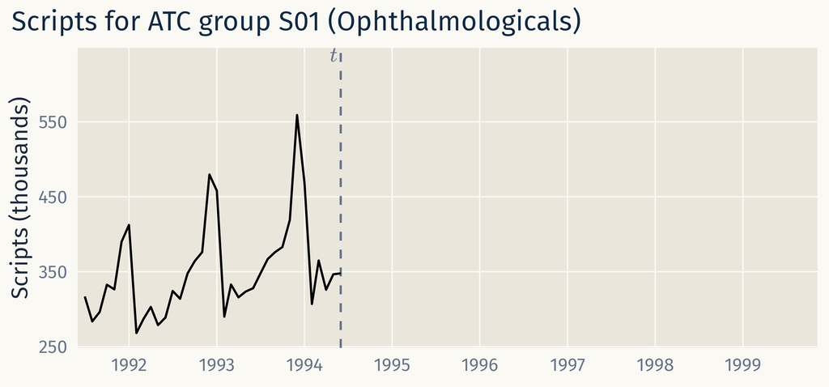

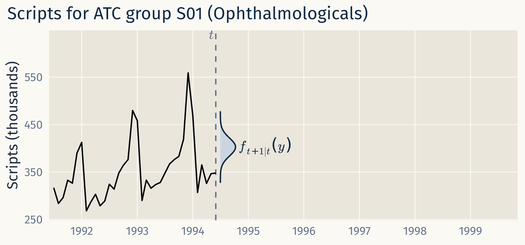

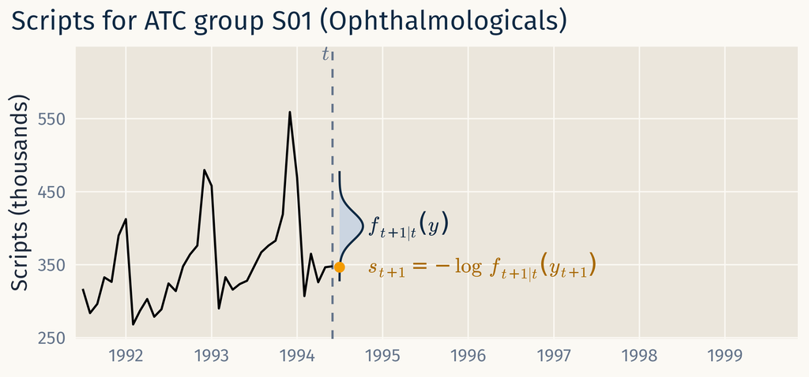

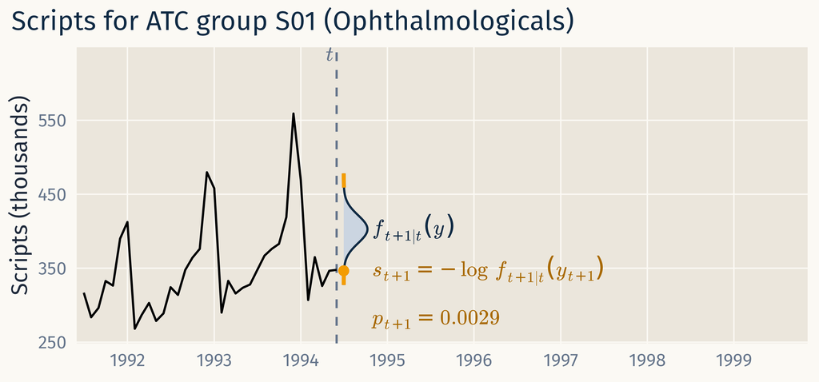

[video not shown]

ETS refitted monthly for every series. Points: $p < 0.01$, $p < 0.001$.